# Rmarkdown_assignment2

Manon Michon

10/2/2019

# About the assignment

# Packages

In order to use the functions needed to execute the code, packages need to be installed and added to the library. Since packages only have to be installed once, they are commented out. Please uncomment and run the install.packages lines if the needed packages still need to be installed. Already installed packages don’t need to be installed again and can simply be loaded and attached to the library using the ‘library’ function. The packages loaded here are all necessary for the correct execution of the code.

```r
#install.packages("WikidataQueryServiceR")
#install.packages("rJava")
#install.packages("rcdk")
#install.packages("pls")

# Load and attach required packages.
library("WikidataQueryServiceR")
library("rJava")
library("rcdk")
library("pls")
```

# Obtaining the data

Before the model can be constructed, data needs to be obtained. The data used in this model is obtained from wikidata using a SPARQL query and is afterwards tested for assumptions. Physicochemical properties such as molecular descriptors are obtained from the github of the rcdk package.

## The SPARQL query

The function ‘query_wikidata’ is able to use the written SPARQL query (stored in ‘sparql_query’) to request the data from wikidata. The result will be stored in a dataframe (‘wikidata_query_result’). Since we are interested in data with solely ‘Kelvin’ as unit, the obtained dataset is subset into a dataframe only consisting of data with ‘Kelvin’ as unit (‘subset_query’). Aliphatic alkanes can also be requested from wikidata using another unit for the boiling point temperature such as ‘Celsius’ or ‘Fahrenheit’. However, it is recommended to keep using ‘Kelvin’ since this is the official scientific notation and a lot of alkanes will only have a boiling point registered in ‘Kelvin’.

```r
# Defining the SPARQL query
sparql_query <- 'SELECT DISTINCT ?comp ?compLabel ?bp ?bpUnit ?bpUnitLabel ?SMILE WHERE {
    ?comp wdt:P31/wdt:P279* wd:Q41581 ;
  p:P2102 [
    ps:P2102 ?bp ;
    psv:P2102/wikibase:quantityUnit  ?bpUnit
    ] ;
  wdt:P233 ?SMILE .
  SERVICE wikibase:label { bd:serviceParam wikibase:language "[AUTO_LANGUAGE],en". }
}'
wikidata_query_result = query_wikidata(sparql_query); # Requesting the query from the wikidata server
```

```
## 134 rows were returned by WDQS
```

```r
# Distinguishing the data with the correct unit for the boiling point and subsetting that data
subset_query = wikidata_query_result[which(wikidata_query_result$bpUnitLabel == 'kelvin'),];
```

## Testing assumptions

The subsetted data is duplicated (‘test_assump_subset’) in order to edit the data without having the chance of accidentally modifying the original subsetted dataset. The data is checked by ordering the boiling points from low to high, and then plotting them into a scatterplot. Outliers can be seen when points do not follow the general trend displayed in the scatterplot. The boiling points are plotted on the y-axis. All points follow the general trend, and no outliers are detected. The general trend is however not linear, which requires further testing for normal distribution. From the histogram it can be concluded that the dataset is not normally distributed. A scatterplot from the dataset in the original order shows that the data -however not normally distributed- is sufficiently unordered to be able to randomly select a train and test dataset.

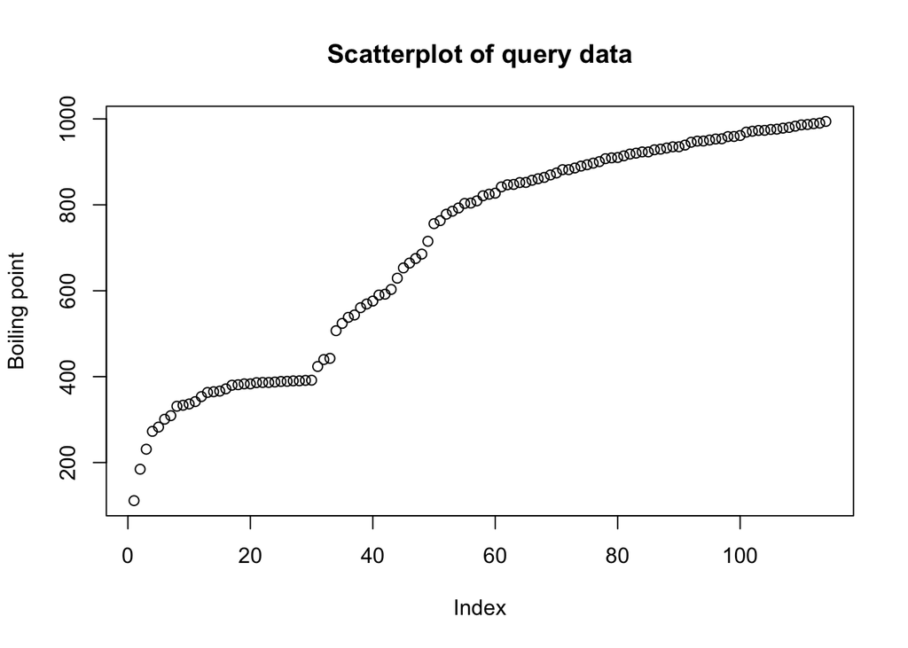

```r
# Duplication of the original dataset to be sure the original dataset stays intact
test_assump_subset = subset_query;
# Ordering the dataset from low to high boiling point
test_assump_subset = test_assump_subset[order(test_assump_subset$bp, decreasing = FALSE),]

# Plotting the boiling points ordered from low to high boiling point to check for outliers
plot(test_assump_subset$bp, main = "Scatterplot of query data", ylab = "Boiling point")
```

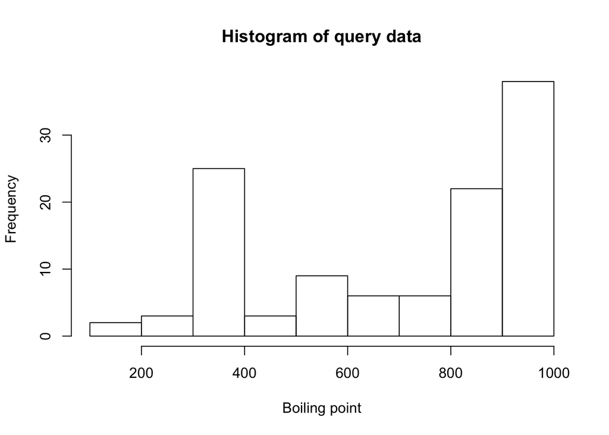

```r
# Histogram to check for normal distribution
hist(test_assump_subset$bp, main = "Histogram of query data", xlab = "Boiling point")
```

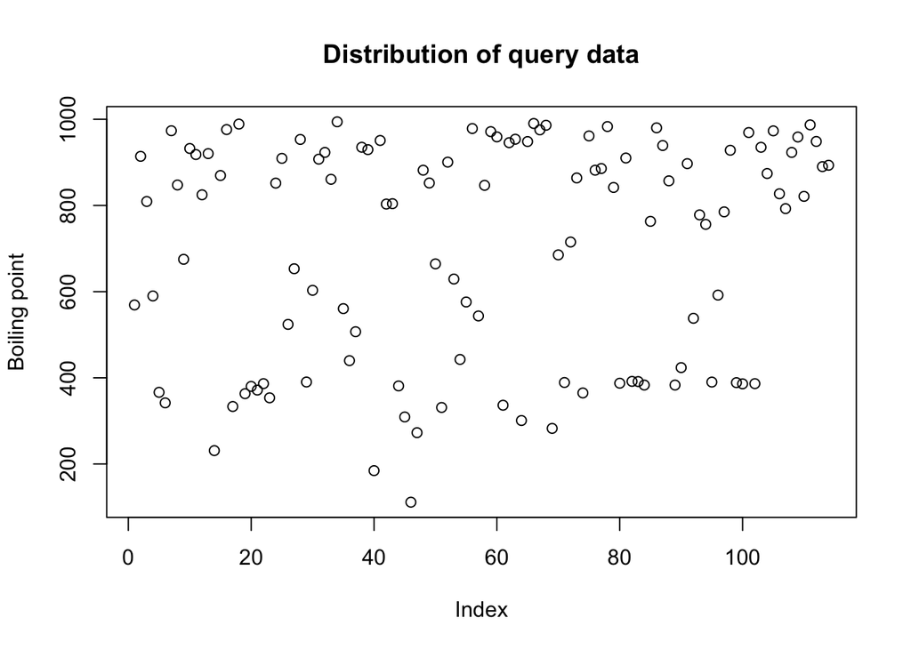

```r
# Checking for inequality of data distribution in the original dataset by plotting the data with no order in boiling point
plot(subset_query$bp, main = "Distribution of query data", ylab = "Boiling point")
```

## Molecular descriptors and dataset editing

Certain columns from the query subset are extracted and renamed to more easily use them at a further point in the process. The chosen physicochemical properties are retrieved from the rcdk github for the selected parsed SMILES. These results are stored in ‘molecular_descriptors’ as a dataframe, to which the boiling points from the wikidata query are added. From this, two subsets are made: a training-set and a test-set. The splitting of the data into a training- and test-set can be done in any matter, based on the random distribution seen above. The way the data is split does however affect the error calculated further on in the model, in a way that when changing the train- and test-dataset, different data is used to construct and test the model. The uniformity of the dataset on which the model is built and tested influences the resulting range of errors from said dataset.

```r
# Renaming column 3 of the subsetted query data to further use and give meaning to this column
bps_measured = subset_query[,3];
# Renaming column 6 of the subsetted query data to further use and give meaning to this column
smiles = subset_query[,6];

parsed_smiles = parse.smiles(subset_query[,6]); # Parses the SMILES given
# Selection of physicochemical properties requested
selected_properties <- c( 'org.openscience.cdk.qsar.descriptors.molecular.WienerNumbersDescriptor',
                'org.openscience.cdk.qsar.descriptors.molecular.APolDescriptor',
                'org.openscience.cdk.qsar.descriptors.molecular.CarbonTypesDescriptor',
                'org.openscience.cdk.qsar.descriptors.molecular.AtomCountDescriptor'
                );
# Request the properties for the selected SMILES
molecular_descriptors = eval.desc(parsed_smiles, selected_properties);

# Binding the molecular descriptors with boiling points from the subsetted query result
moldesc_dataset = cbind(molecular_descriptors, bps_measured)
desc_test = moldesc_dataset[1:20,]; # Establishing a test-dataset with the first twenty alkanes
desc_train = moldesc_dataset[21:114,] # Establishing a train-dataset with the rest of the alkanes
```

# The Model

A Partial Least Squares Regression model is constructed using the PLS package to investigate whether the boiling points of the aliphatic alkanes can be predicted. The model is validated using the Leave-One-Out validation method from the PLS package.

## Construction of the Model and training

The model is constructed using all of the selected molecular descriptors. The number of components is left empty. The model is validated using a Leave-One-Out validation method. The RMSEP (Root Mean Square Error of Prediction) plot shows the expected error for each number of components used in the model. The error is more or less the same for all number of components higher than one. Using the lowest amount of component ensures that the model is not overfitted. Based on this graph, the number of components used for testing will be 2. The scatterplot of the model shows the distribution of the training-data along the regression line constructed by a 2-component model.

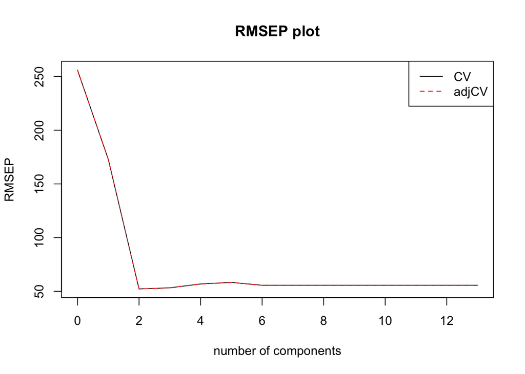

```r
# Construction of the Partial Least Square model
PLStest = plsr(bps_measured ~ ., data = desc_train, validation = "LOO");
# Plotting the error for each amount of latent variables considered
plot(RMSEP(PLStest), legendpos = "topright", main = "RMSEP plot")
```

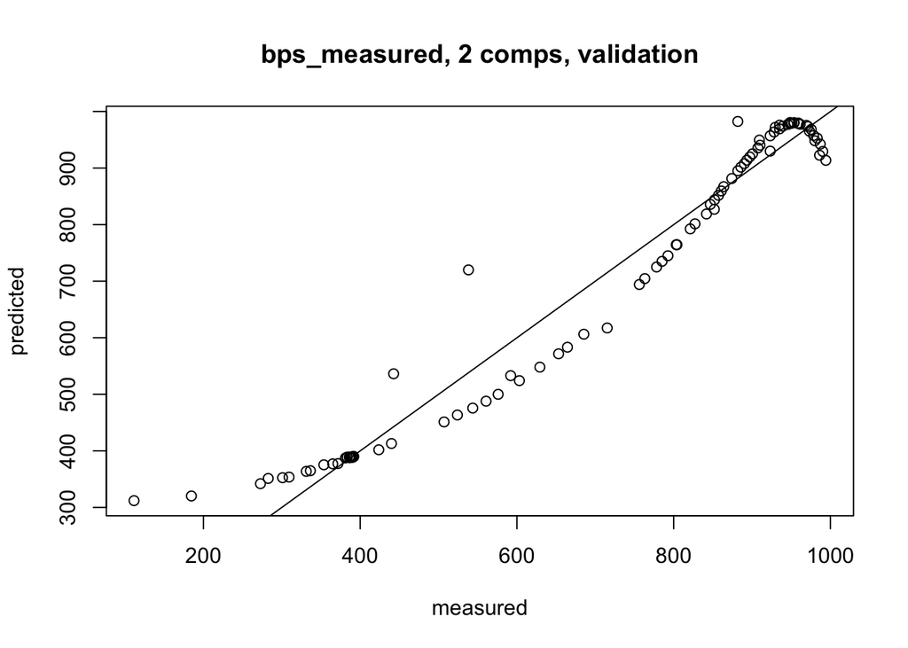

```r
plot(PLStest, ncomp = 2, line = TRUE) # Visualisation of the PLS model in combination with the training data
```

## Testing of the model

```r
predict(PLStest, ncomp = 2, newdata = desc_test); # Prediction of boiling points using the test data
```

```
## , , 2 comps
##
##                                                                                                   bps_measured
## CC.C.CCCC.C.CCCC.C.CCCC.C.C                                                                           521.9635
## CCCCCCCCCCCCCCCCCCCCCCCCCCCCCCCCCCCCCCCCCCCCCCCCCCCCCCCCCCCCCCCCCC                                    944.0851
## CCCCCCCCCCCCCCCCCCCCCCCCCCCCCCCCCCCCCCCCCC                                                            774.8215
## CCCCCCCCCCCCCCCCCC                                                                                    513.4739
## CCC.CC.CC                                                                                             377.2076
## CCCCCC                                                                                                364.7121
## CCCCCCCCCCCCCCCCCCCCCCCCCCCCCCCCCCCCCCCCCCCCCCCCCCCCCCCCCCCCCCCCCCCCCCCCCCCCCCCCCCCCCCCCC             971.1966
## CCCCCCCCCCCCCCCCCCCCCCCCCCCCCCCCCCCCCCCCCCCCCC                                                        810.8479
## CCCCCCCCCCCCCCCCCCCCCCCCC                                                                             596.1172
## CCCCCCCCCCCCCCCCCCCCCCCCCCCCCCCCCCCCCCCCCCCCCCCCCCCCCCCCCCCCCCCCCCCCCCCC                              965.8465
## CCCCCCCCCCCCCCCCCCCCCCCCCCCCCCCCCCCCCCCCCCCCCCCCCCCCCCCCCCCCCCCCCCCCCC                                959.6483
## CCCCCCCCCCCCCCCCCCCCCCCCCCCCCCCCCCCCCCCCCCC                                                           784.0774
## CCCCCCCCCCCCCCCCCCCCCCCCCCCCCCCCCCCCCCCCCCCCCCCCCCCCCCCCCCCCCCCCCCCC                                  952.3843
## CCC                                                                                                   326.7509
## CCCCCCCCCCCCCCCCCCCCCCCCCCCCCCCCCCCCCCCCCCCCCCCCCCCCCC                                                874.2525
## CCCCCCCCCCCCCCCCCCCCCCCCCCCCCCCCCCCCCCCCCCCCCCCCCCCCCCCCCCCCCCCCCCCCCCCCCCCCCCCCCCCCCCCCCCCC          962.5105
## CCCC.C.C                                                                                              363.3806
## CCCCCCCCCCCCCCCCCCCCCCCCCCCCCCCCCCCCCCCCCCCCCCCCCCCCCCCCCCCCCCCCCCCCCCCCCCCCCCCCCCCCCCCCCCCCCCCCC     940.9793
## CCCCC.C.C                                                                                             375.9976
## CC.C..C.C.C..C.C                                                                                      388.3857
```

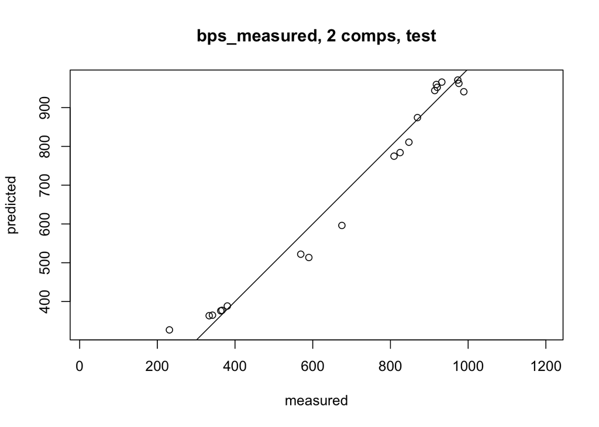

```r
predplot(PLStest, ncomp = 2, newdata = desc_test, asp = 1, line = TRUE) # The test data is plotted
```

```r
RMSEP(PLStest, newdata = desc_test) # RMSEP for each of the possible components for the test dataset
```

```
## (Intercept)      1 comps      2 comps      3 comps      4 comps
##      259.75       177.54        42.83        44.80        44.34
##     5 comps      6 comps      7 comps      8 comps      9 comps
##       47.15        48.02        48.02        48.02        48.02
##    10 comps     11 comps     12 comps     13 comps
##       48.02        48.02        48.02        48.02
```